# Analyzing resting-state EEG and Spelling Performance in Young Adults (Gamma)

Leandro Ledesma

2024-12-24

### Universal block code settings

```r
knitr::opts_chunk$set(echo = FALSE)
knitr::opts_chunk$set(message = FALSE)
knitr::opts_chunk$set(comment = NULL)
knitr::opts_chunk$set(warning = FALSE)
```

### Load in the data manipulation packages first

### Index subjects by those that met the requirements

- No self-report injury
- No Epilepsy
- Removing missing data
- No one below ‘IQ’ of 70 (more than 2 SD below the mean)
- Extremely poor spellers (more than 3 SD below the mean)
- Issues with EEG recordings
- Did not survive EEG cleaning

### Missing data

- All data should be present based on the index from the previous section

This is an automated response: The current dataset has the dimensions 449 x 23 . Below is a frequency table showing the number of missing data for each variable.

[output not shown]

This is an automated response: Our final sample size is n= 449

## Research Question

- We are interested in investigating spelling performance as a predictor of EEG activity. We hypothesize that spelling ability will result in differences in brain activity while controlling for covariates like Age, Group (Bio vs Ins), and topography.

## Descriptive statistics of the data

We can use the describe() function from the psych package to give us descriptive statistics from the variables that will be incorporated into the model. We will create 3 tables. The first will contain information about the continuous predictors. The next will have the frequency of the categorical variables. Lastly we will have a table for the resting-state EEG frequency bands.

We will be creating models for 4 differenet frequency bands (delta, theta, alpha, beta), thus, four datasets will be created where only information related to a specific frequency band are present.

### Descriptives of our data

```
                    vars   n  mean   sd median trimmed  mad   min   max range
Age                    1 449 20.27 4.44  19.00   19.55 2.97 15.00 36.00 21.00
Raw.Scores             2 449 30.87 5.37  32.00   31.20 4.45 18.00 42.00 24.00
Total_SpellingError    3 449 13.38 8.62  12.00   12.60 8.90  0.00 41.00 41.00
frontal_delta          4 449  2.48 1.67   1.97    2.19 0.96  0.49 13.18 12.69
frontal_theta          5 449  0.49 0.36   0.38    0.42 0.20  0.11  3.32  3.20
frontal_alpha          6 449  1.11 1.04   0.81    0.94 0.69  0.07  8.85  8.78
frontal_beta           7 449  0.10 0.07   0.08    0.09 0.04  0.03  0.88  0.85
temporal_delta         8 449  1.46 0.77   1.26    1.35 0.57  0.34  6.08  5.75
temporal_theta         9 449  0.51 0.43   0.37    0.43 0.22  0.10  3.57  3.47
temporal_alpha        10 449  0.90 0.65   0.74    0.82 0.53  0.07  3.48  3.42
temporal_beta         11 449  0.15 0.11   0.12    0.13 0.06  0.02  0.99  0.97
parietal_delta        12 449  1.14 0.69   0.97    1.04 0.43  0.32  5.94  5.62
parietal_theta        13 449  0.48 0.49   0.32    0.38 0.22  0.07  3.96  3.89
parietal_alpha        14 449  1.71 1.68   1.19    1.42 1.06  0.05 12.34 12.28
parietal_beta         15 449  0.10 0.06   0.08    0.09 0.05  0.01  0.35  0.34
occipital_delta       16 449  2.12 1.45   1.71    1.90 0.83  0.39 14.37 13.97
occipital_theta       17 449  0.86 0.82   0.60    0.70 0.45  0.12  6.89  6.77
occipital_alpha       18 449  4.31 4.44   3.04    3.52 2.88  0.07 35.74 35.67
occipital_beta        19 449  0.21 0.15   0.18    0.19 0.09  0.04  1.63  1.59
                     skew kurtosis   se
Age                  1.38     1.35 0.21
Raw.Scores          -0.54    -0.32 0.25
Total_SpellingError  0.73    -0.01 0.41
frontal_delta        2.55     8.82 0.08
frontal_theta        2.70    11.65 0.02
frontal_alpha        2.69    11.71 0.05
frontal_beta         4.94    41.52 0.00
temporal_delta       1.89     5.55 0.04
temporal_theta       3.11    13.66 0.02
temporal_alpha       1.30     1.68 0.03
temporal_beta        2.81    13.35 0.00
parietal_delta       2.71    11.70 0.03
parietal_theta       2.94    11.68 0.02
parietal_alpha       2.38     8.10 0.08
parietal_beta        1.42     2.17 0.00
occipital_delta      3.37    19.49 0.07
occipital_theta      2.86    11.95 0.04
occipital_alpha      2.59     9.95 0.21
occipital_beta       3.54    23.90 0.01
```

```
  F   M
256 193
```

```
 BF  IC
246 203
```

### Visualizing all continuous variables as histograms (Z-scores)

- This drives home the message that the outcome variable is highly skewed to the right in all possible combinations of FB and Topography.

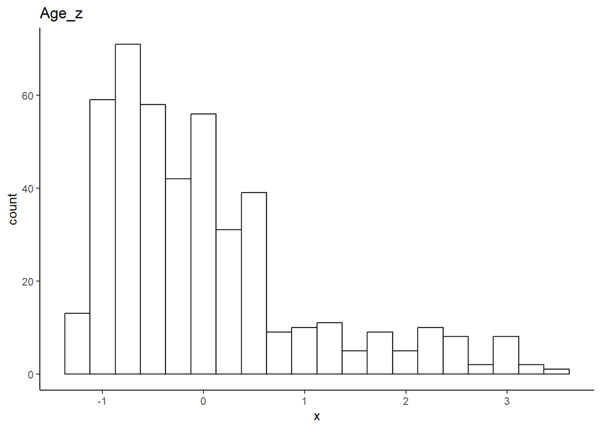

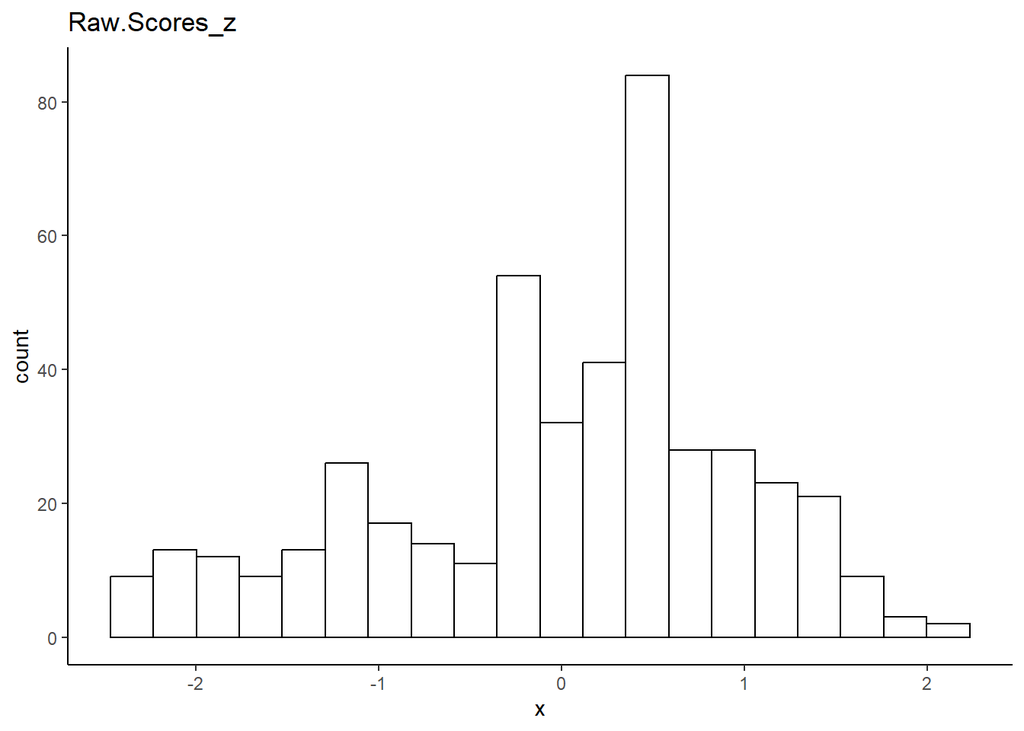

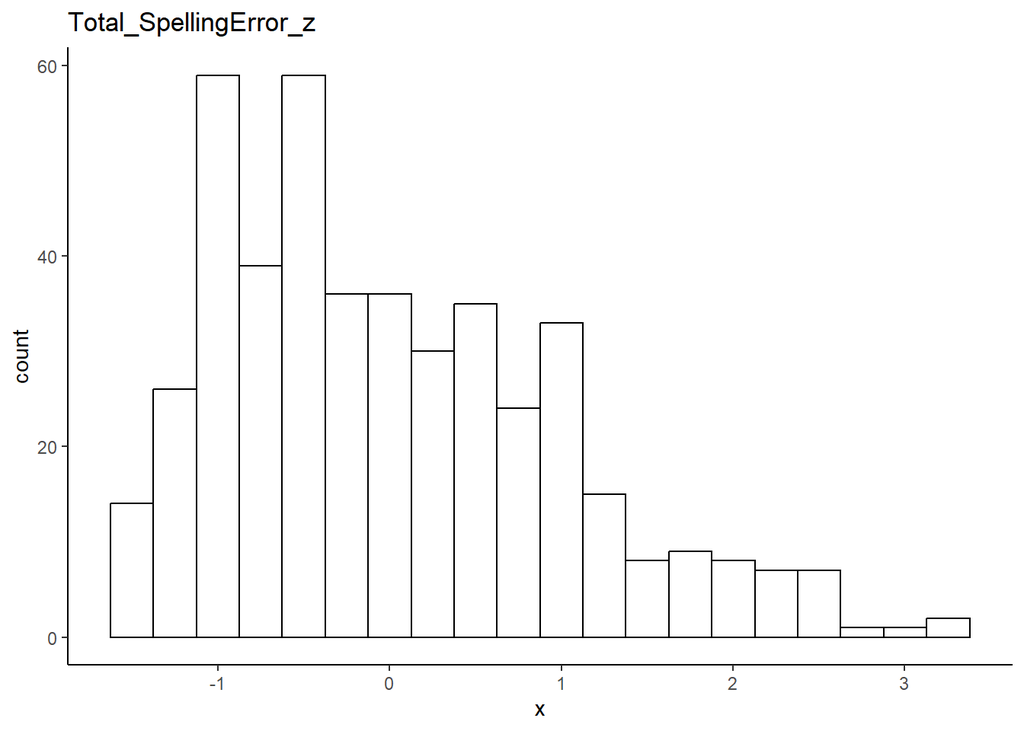

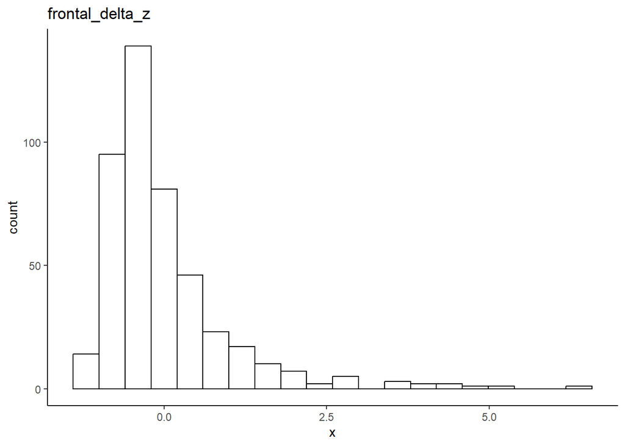

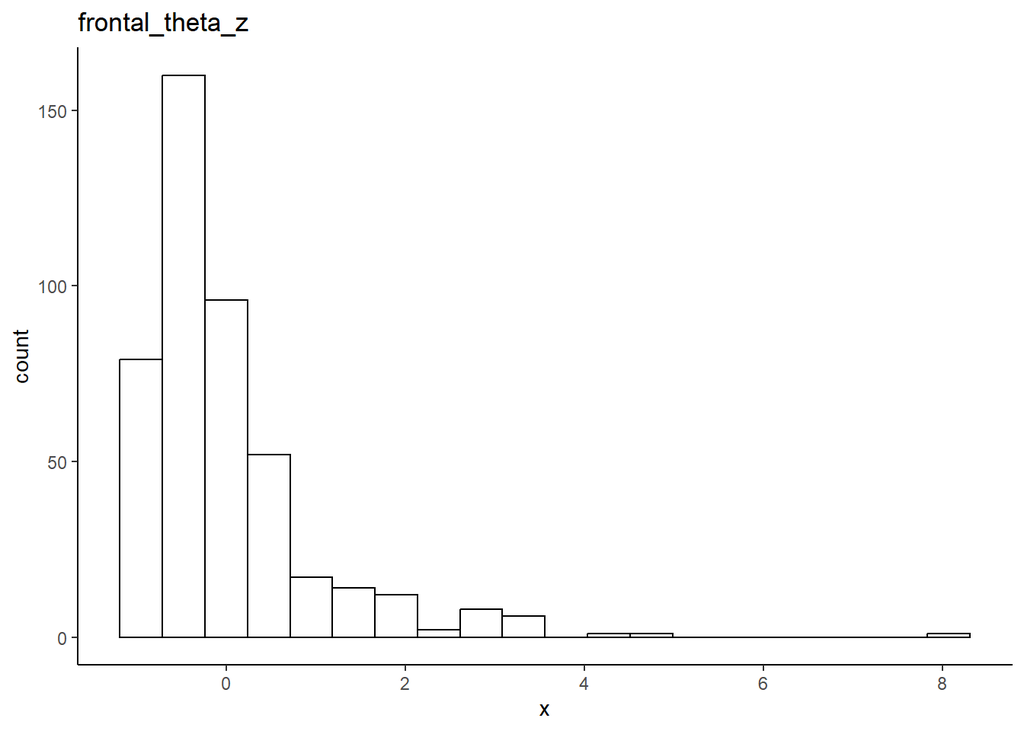

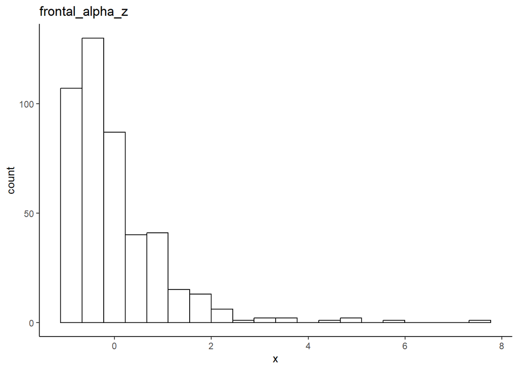

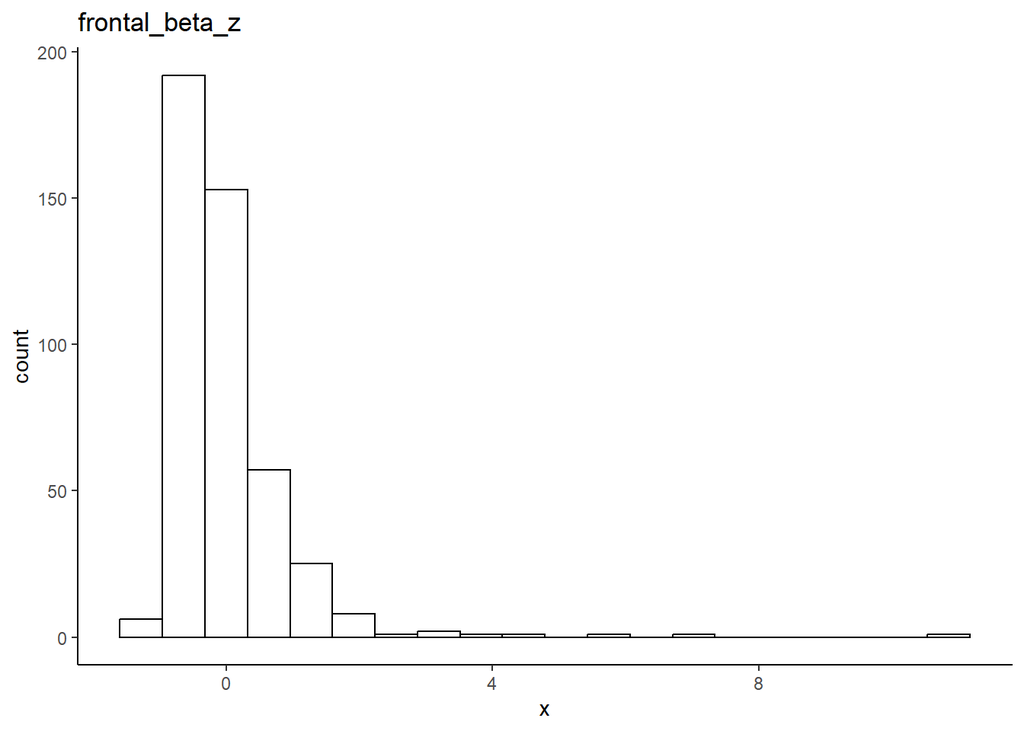

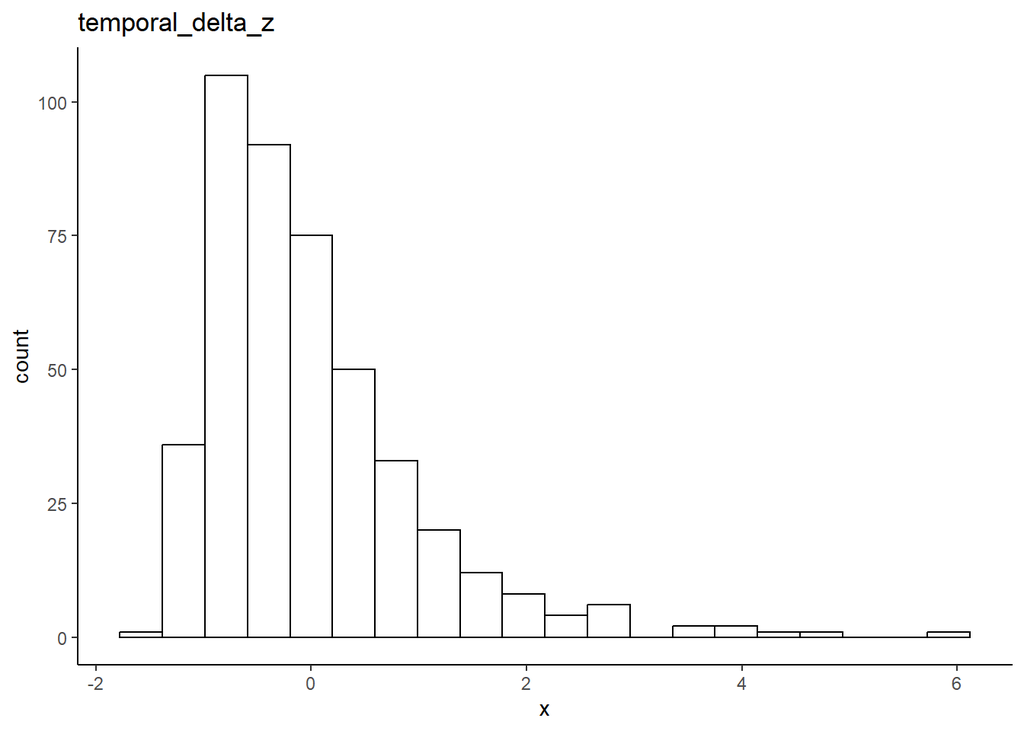

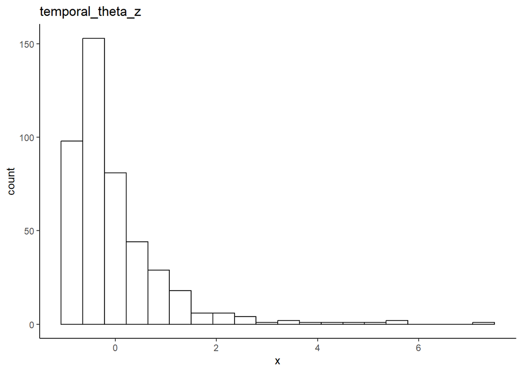

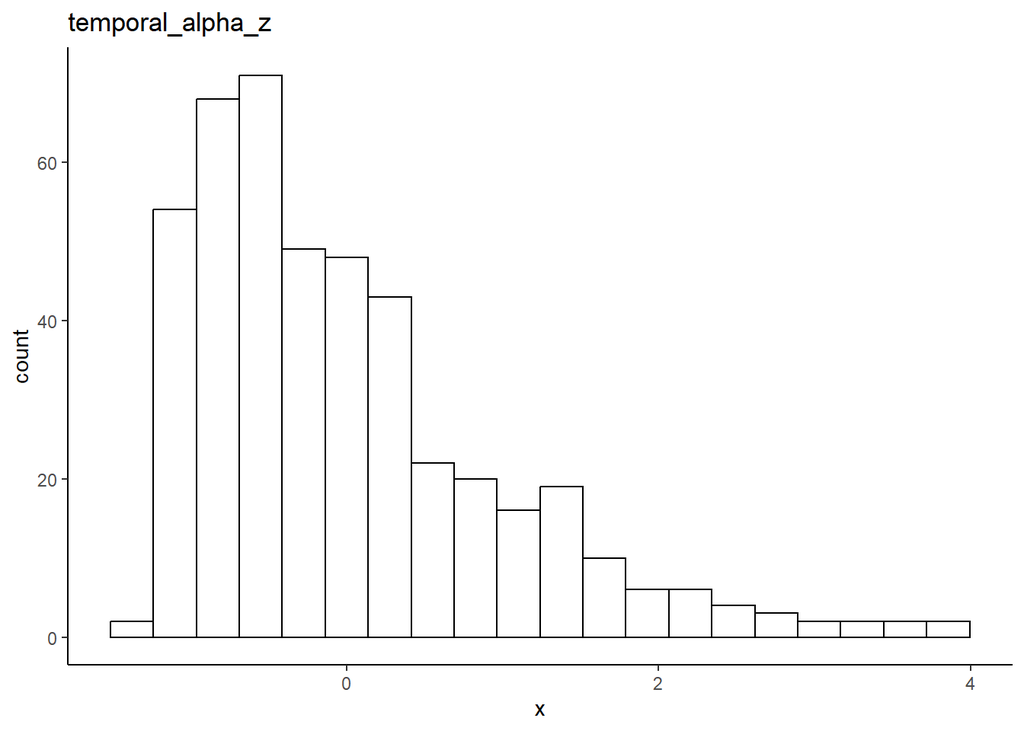

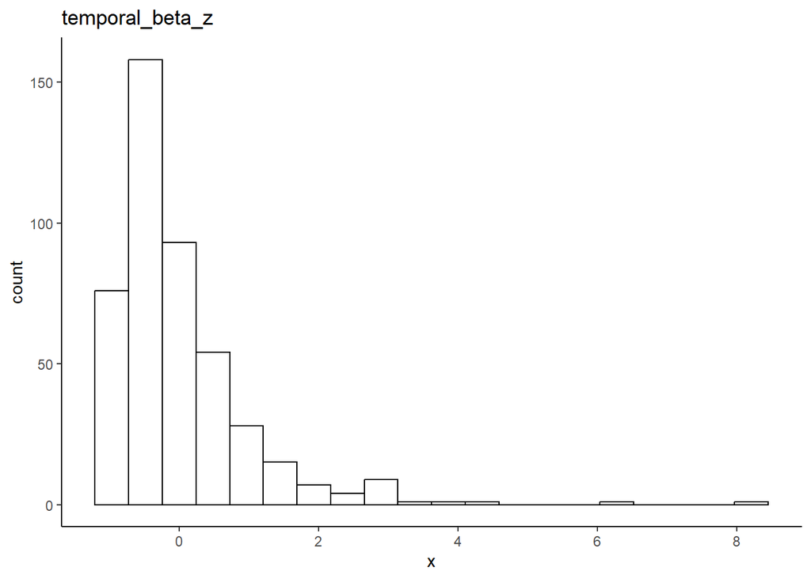

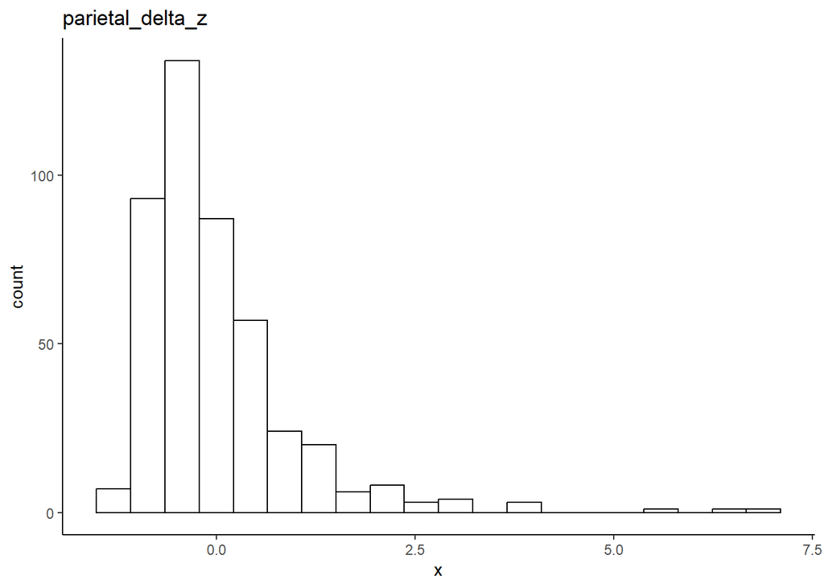

[7 more figures not shown]

### Testing for Multicollinearity

- We need to drop predictors that are highly correlated with each other
- Raw scores and total spelling error is kinda high but I think okay

```
                            Age  Raw.Scores Total_SpellingError
Age                  1.00000000  0.09727325          -0.2088876
Raw.Scores           0.09727325  1.00000000          -0.6123482
Total_SpellingError -0.20888759 -0.61234825           1.0000000
```

### Check for independence between categorical variables

P-value is significant. It seems there are more females who were raised in biological families than males. This may not be as big of a deal as initially thought.

```
     Group
Sex    BF  IC Sum
  F   153 103 256
  M    93 100 193
  Sum 246 203 449
```

```
   Group
Sex    BF    IC
  F 0.341 0.229
  M 0.207 0.223
```

```
    Pearson's Chi-squared test with Yates' continuity correction

data:  contingency.table
X-squared = 5.4978, df = 1, p-value = 0.01904
```

### Preparing Data for Modeling

We see here that the z-score distribution is larger, but that is highly likely to having power from different brain regions all in one vector AND frequency bands. We can confirm this with boxplots.

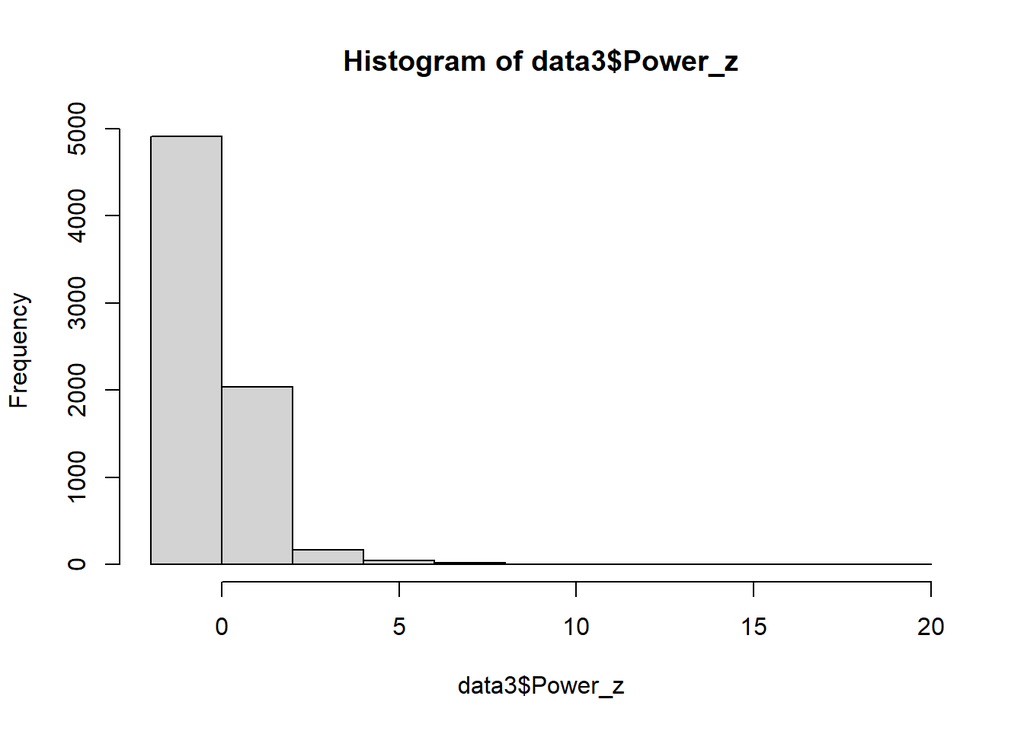

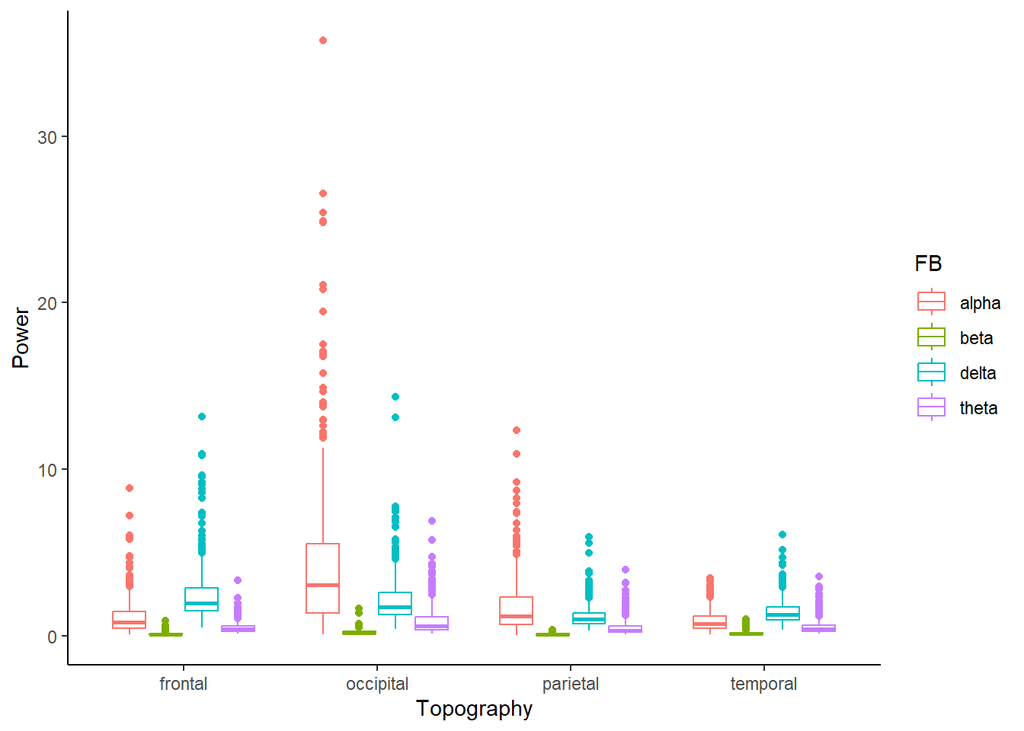

```
# A tibble: 20 × 11
      ID Sex     Age Group Raw.Scores Total_SpellingError Condition Power
   <dbl> <chr> <dbl> <chr>      <int>               <int> <chr>     <dbl>
 1 15473 F        16 IC            35                  10 Closed     35.7
 2 37582 M        16 IC            30                  18 Closed     26.6
 3 45965 F        29 BF            34                   9 Closed     25.4
 4 29847 F        25 BF            33                   2 Closed     24.9
 5 97251 F        17 IC            31                  13 Closed     24.8
 6 13465 M        17 BF            32                  12 Closed     21.1
 7 61140 F        21 BF            37                   5 Closed     20.8
 8 99982 M        17 IC            21                  23 Closed     19.5
 9 69996 M        18 BF            27                   5 Closed     17.5
10 66550 F        16 IC            31                   9 Closed     17.1
11 73967 F        16 BF            32                   5 Closed     17.0
12 58571 M        16 IC            29                  24 Closed     16.8
13 80941 F        19 IC            29                  17 Closed     15.8
14 10974 F        21 BF            29                   4 Closed     14.9
15 91509 F        16 BF            35                  10 Closed     14.7
16 85115 M        22 BF            35                   7 Closed     14.0
17 41857 M        19 IC            25                  17 Closed     14.0
18 32115 F        17 BF            38                   1 Closed     13.9
19 27152 F        18 BF            39                   5 Closed     13.9
20 57285 F        31 BF            33                   5 Closed     13.8
# ℹ 3 more variables: Topography <chr>, FB <chr>, Power_z <dbl>
```

```
# A tibble: 20 × 11
      ID Sex     Age Group Raw.Scores Total_SpellingError Condition Power
   <dbl> <chr> <dbl> <chr>      <int>               <int> <chr>     <dbl>
 1 10510 M        17 BF            34                  18 Closed    4.13
 2 11672 M        19 IC            33                  12 Closed    3.72
 3 11754 F        20 IC            36                   8 Closed    1.83
 4 15217 F        26 BF            35                   3 Closed    2.87
 5 16293 F        19 BF            22                  13 Closed    0.158
 6 18540 F        16 BF            23                  18 Closed    4.67
 7 21880 M        20 IC            27                  13 Closed    2.50
 8 22187 F        29 BF            19                   8 Closed    2.82
 9 22291 M        31 BF            36                  13 Closed    2.34
10 25314 M        22 BF            40                   6 Closed    0.411
11 28848 M        30 IC            28                  23 Closed    2.00
12 34307 F        16 BF            29                  13 Closed    0.896
13 34902 F        27 IC            26                  21 Closed    2.98
14 35046 F        18 BF            28                  22 Closed    5.68
15 44017 F        16 IC            32                  15 Closed    3.72
16 48938 F        20 BF            37                   5 Closed    1.37
17 49406 M        31 BF            30                   9 Closed    4.56
18 49864 F        21 BF            36                   7 Closed    4.03
19 54663 F        17 BF            22                   8 Closed    1.00
20 55748 F        20 IC            32                  14 Closed    1.02
# ℹ 3 more variables: Topography <chr>, FB <chr>, Power_z <dbl>
```

### Removing Outliers

In the boxplot above, We can see what what is driving the difference in the data is alpha power in the occipital region since it is much larger than in other FB x regions. A potential solution to removing outliers in the data might be to remove any data points within a topography x FB that is more than 3 SD from their mean. We can do that I believe by grouping the data and then scaling the power using the mutate() function.

We will then remove the values that are 3 SD from the means of their respective groups- since we will be using mixed effects models, we do not have to drop the ID entirely if they are missing data since the model can handle it.

```
[1] 449
```

```
[1] "Removed 134 observations from the dataset"
```

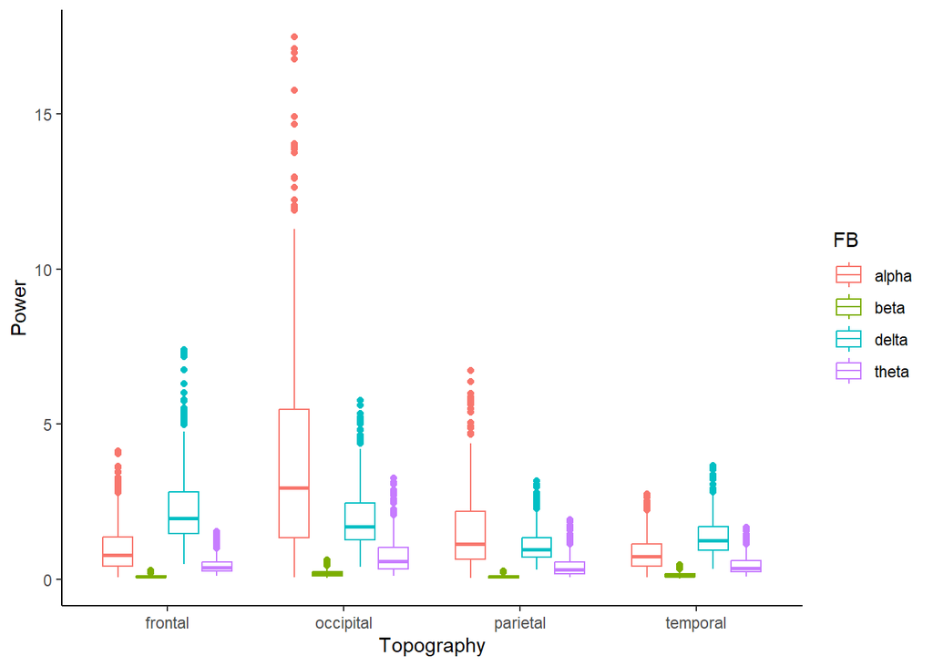

### Running our models

As mentioned, we are interested in how spelling performance may potentially influence electrical brain activity. To do this, we will be creating a **generalized linear mixed effects model (GLMM)** with a gamma distribution and **log** link function. This is because the distribution of the outcome power (which is a value representing averaged amplitudes within a frequency range/band) is positive and skewed to the right, which will produced skewed errors. A Gamma distribution can better fit our data. Additionally, the introduction of topographical regions as a factor requires subjects to have their own random intercept. This is because we may expect brain regions to be more similar to each other within a person than across- thus, this needs to be taken into account by introducing subjects as a random effect.

The log link part is important and different from a logit link. The similarity is that exp() is used to represent these values into a number that is easier to understand. For the ‘log’ link, exp() converts it into a **raw score**- so in a way, it seems that exp() estimates is like turned them back into regular estimates that can be interpreted linearly (as one unit increase we expect this increase for the outcome) instead of as a probability. This is information obtain from ChatGPT.

We will use model comparison to see which model would be the best to interpret- however, if the model of best fit is too difficulty/complex, then we may chose the second best model.

```
# Intraclass Correlation Coefficient

    Adjusted ICC: 0.240
  Unadjusted ICC: 0.240
```

```
Data: data4
Models:
mod0: Power ~ 1 + (1 | ID)
mod1: Power ~ Age + (1 | ID)
mod2: Power ~ Age + Topography + (1 | ID)
mod3: Power ~ Age + Topography + Total_SpellingError + (1 | ID)
mod4: Power ~ Age + Topography * Total_SpellingError + (1 | ID)
mod6: Power ~ Age * Topography * Total_SpellingError + (1 | ID)
     npar   AIC   BIC  logLik deviance    Chisq Df Pr(>Chisq)
mod0    3 14182 14202 -7087.8    14176
mod1    3 14648 14669 -7321.2    14642   0.0000  0
mod2    6 13873 13914 -6930.3    13861 781.7137  3    < 2e-16 ***
mod3    7 13875 13923 -6930.3    13861   0.0225  1    0.88082
mod4   10 13880 13948 -6929.9    13860   0.9396  3    0.81587
mod6   17 13880 13996 -6922.9    13846  13.9293  7    0.05245 .
---
Signif. codes:  0 '***' 0.001 '**' 0.01 '*' 0.05 '.' 0.1 ' ' 1
```

```
Data: data4
Models:
mod0: Power ~ 1 + (1 | ID)
mod1: Power ~ Age + (1 | ID)
mod2: Power ~ Age + Topography + (1 | ID)
mod3: Power ~ Age + Topography + Total_SpellingError + (1 | ID)
mod5: Power ~ Age * Total_SpellingError + Topography + (1 | ID)
mod6: Power ~ Age * Topography * Total_SpellingError + (1 | ID)
     npar   AIC   BIC  logLik deviance    Chisq Df Pr(>Chisq)
mod0    3 14182 14202 -7087.8    14176
mod1    3 14648 14669 -7321.2    14642   0.0000  0
mod2    6 13873 13914 -6930.3    13861 781.7137  3  < 2.2e-16 ***
mod3    7 13875 13923 -6930.3    13861   0.0225  1   0.880817
mod5    8 13867 13922 -6925.5    13851   9.5966  1   0.001949 **
mod6   17 13880 13996 -6922.9    13846   5.2723  9   0.809954
---
Signif. codes:  0 '***' 0.001 '**' 0.01 '*' 0.05 '.' 0.1 ' ' 1
```

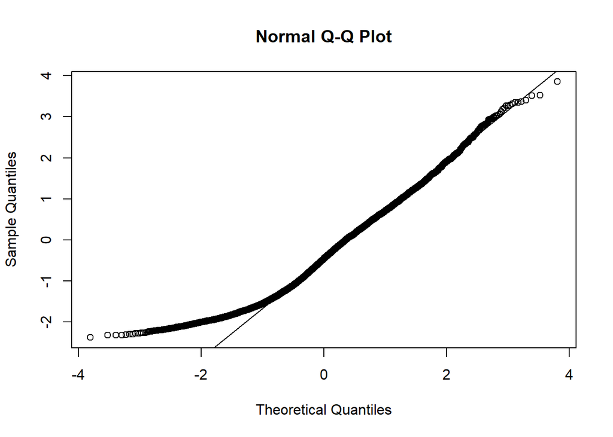

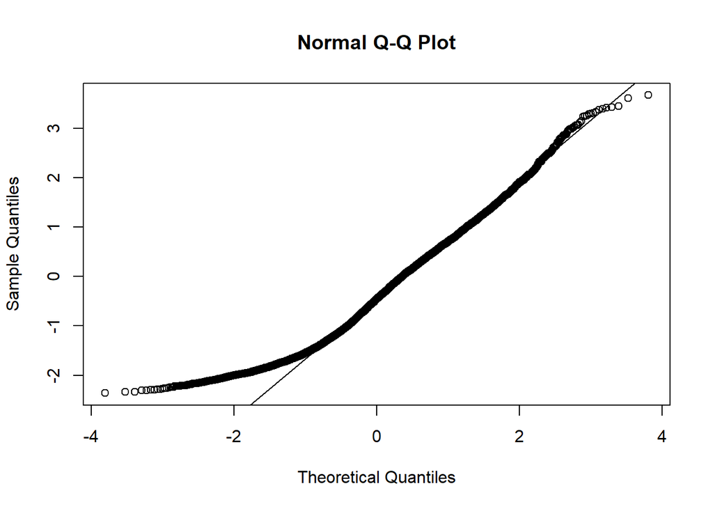

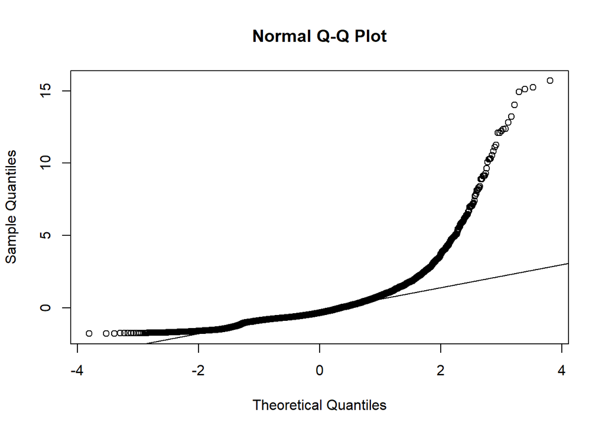

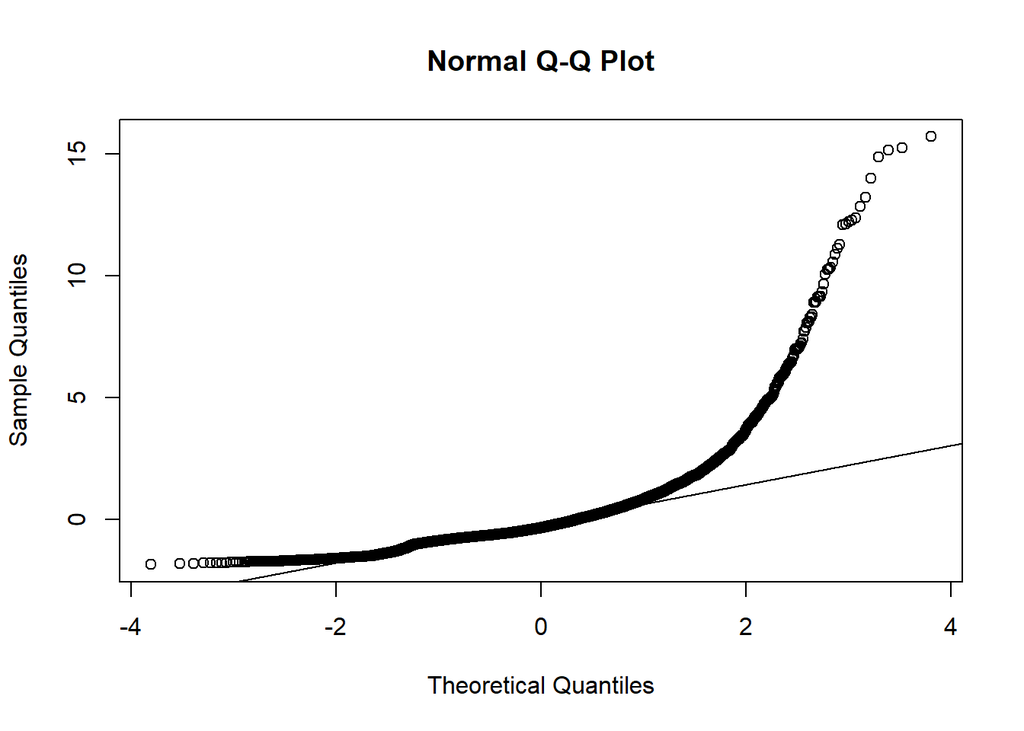

## Identifying and removing outliers

While the Gamma Log Link functions models look better at handling the EEG data than guassian, we still see that there can be some improvement. Thus, we will now check using cook’s distance if there are any outliers in the data, and if so to remove them.

We will be doing this for both mod4 and mod5

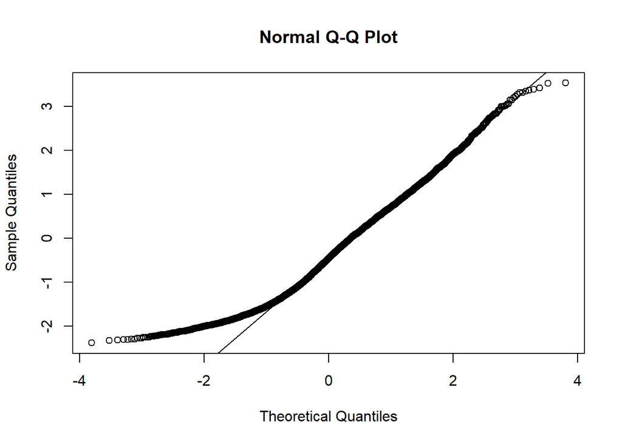

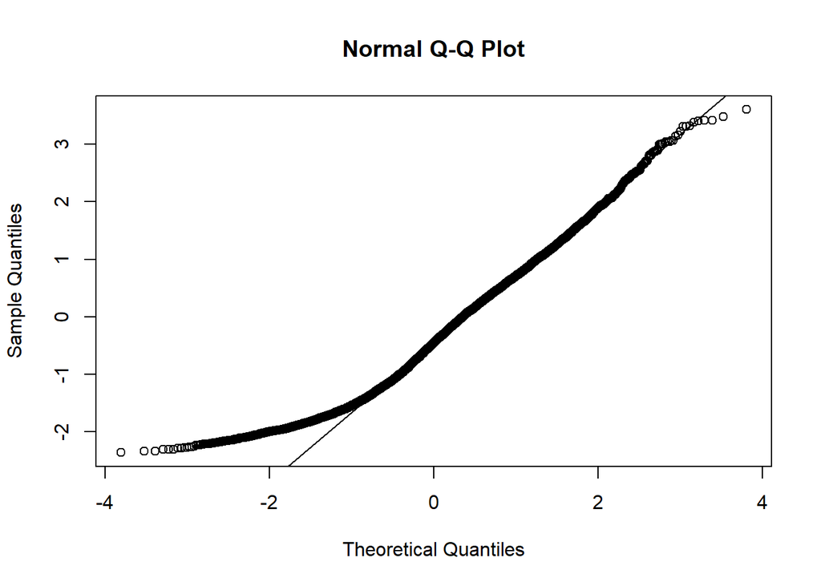